# Proyecto Final LendingClub Loan Study

Gerardo Salas Montoya

Melissa Villalta Solano

22 December 2018

## DAT001 Lenguajes de programacion orientados al análisis de datos

## Objetivo

Este es el proyecto final correspondiente al curso *DAT001 Lenguajes orientados al análisis de datos* el cual consiste en desarrollar un analisis que aplique los temas vistos en clase.

El proyecto consiste en seleccionar una base de datos, analizar los datos y definir un objetivo general del proyecto, el cual consiste en solucionar un problema que se pueda resolver por medio de los datos en la base.

**Durante el proyecto, se deben aplicar las técnicas de limpieza de datos y de vectorización que se vieron durante el curso.**

## Business Understanding

Lending Club es una plataforma donde las personas pueden pedir y dar préstamos personales para diferentes tipos de proyectos. Lending Club les permite a los prestatarios crear préstamos personales sin garantía entre **$1,000** y **$40,000** con un período de préstamo estándar de tres años. Los inversores pueden buscar y navegar en las listas de préstamos en el sitio web de Lending Club y seleccionar los préstamos en los que desean invertir en función de la información suministrada sobre el prestatario, el monto del préstamo, el grado del préstamo y el propósito del préstamo. Los inversores hacen dinero con intereses. Lending Club gana dinero al cobrar a los prestatarios una tarifa de originación y a los inversores una tarifa de servicio.

### Problema

La gerencia de LendingClub ha solicitado un estudio estadistico con el fin de identificar areas de mejora y poder realizar un marketing mas personalizado. El estudio se enfoca en clasificar e identificar las relaciones que existen entre las diferentes variables.

## Data Understanding

Los datos contiene *143* variables y *42538* observaciones. El rango de los datos es del 2007 al 2011.

El diccionario de datos:

| LoanStatNew | Description |
| --- | --- |
| acc_now_delinq | The number of accounts on which the borrower is now delinquent. |
| acc_open_past_24mths | Number of trades opened in past 24 months. |
| addr_state | The state provided by the borrower in the loan application |
| all_util | Balance to credit limit on all trades |
| annual_inc | The self-reported annual income provided by the borrower during registration. |
| annual_inc_joint | The combined self-reported annual income provided by the co-borrowers during registration |
| application_type | Indicates whether the loan is an individual application or a joint application with two co-borrowers |
| avg_cur_bal | Average current balance of all accounts |
| bc_open_to_buy | Total open to buy on revolving bankcards. |
| bc_util | Ratio of total current balance to high credit/credit limit for all bankcard accounts. |
| chargeoff_within_12_mths | Number of charge-offs within 12 months |
| collection_recovery_fee | post charge off collection fee |
| collections_12_mths_ex_med | Number of collections in 12 months excluding medical collections |
| delinq_2yrs | The number of 30+ days past-due incidences of delinquency in the borrower’s credit file for the past 2 years |
| delinq_amnt | The past-due amount owed for the accounts on which the borrower is now delinquent. |
| desc | Loan description provided by the borrower |
| dti | A ratio calculated using the borrower’s total monthly debt payments on the total debt obligations, excluding mortgage and the requested LC loan, divided by the borrower’s self-reported monthly income. |
| dti_joint | A ratio calculated using the co-borrowers’ total monthly payments on the total debt obligations, excluding mortgages and the requested LC loan, divided by the co-borrowers’ combined self-reported mont… |
| earliest_cr_line | The month the borrower’s earliest reported credit line was opened |
| emp_length | Employment length in years. Possible values are between 0 and 10 where 0 means less than one year and 10 means ten or more years. |
| emp_title | The job title supplied by the Borrower when applying for the loan.* |
| fico_range_high | The upper boundary range the borrower’s FICO at loan origination belongs to. |
| fico_range_low | The lower boundary range the borrower’s FICO at loan origination belongs to. |
| funded_amnt | The total amount committed to that loan at that point in time. |
| funded_amnt_inv | The total amount committed by investors for that loan at that point in time. |
| grade | LC assigned loan grade |
| home_ownership | The home ownership status provided by the borrower during registration or obtained from the credit report. Our values are: RENT, OWN, MORTGAGE, OTHER |
| id | A unique LC assigned ID for the loan listing. |
| il_util | Ratio of total current balance to high credit/credit limit on all install acct |
| initial_list_status | The initial listing status of the loan. Possible values are – W, F |

[output cut: 124 more lines]

## Data Preparation

Se seleccionarion 47 columnas a utilizar en la exploracion de datos.

|  | loan_amnt | funded_amnt | funded_amnt_inv | term | int_rate | installment |
| --- | --- | --- | --- | --- | --- | --- |
|  | Min. : 500 | Min. : 500 | Min. : 0 | Length:42538 | Length:42538 | Min. : 15.67 |
|  | 1st Qu.: 5200 | 1st Qu.: 5000 | 1st Qu.: 4950 | Class :character | Class :character | 1st Qu.: 165.52 |
|  | Median : 9700 | Median : 9600 | Median : 8500 | Mode :character | Mode :character | Median : 277.69 |
|  | Mean :11090 | Mean :10822 | Mean :10140 | NA | NA | Mean : 322.62 |
|  | 3rd Qu.:15000 | 3rd Qu.:15000 | 3rd Qu.:14000 | NA | NA | 3rd Qu.: 428.18 |
|  | Max. :35000 | Max. :35000 | Max. :35000 | NA | NA | Max. :1305.19 |
|  | NA’s :3 | NA’s :3 | NA’s :3 | NA | NA | NA’s :3 |

## Data Mining

### Prestamos por tipo de Solicitud

El siguiente WordCloud muestra los propositos por los cuales se ha solicitado un prestamo. En este se aprecia que **“Consolidacion de Deudas (debyConsolid)”** es el principal proposito por los cuales se solicita un prestamo, seguido por **Tarjetas de Credito** y **Mejoras para el hogar**

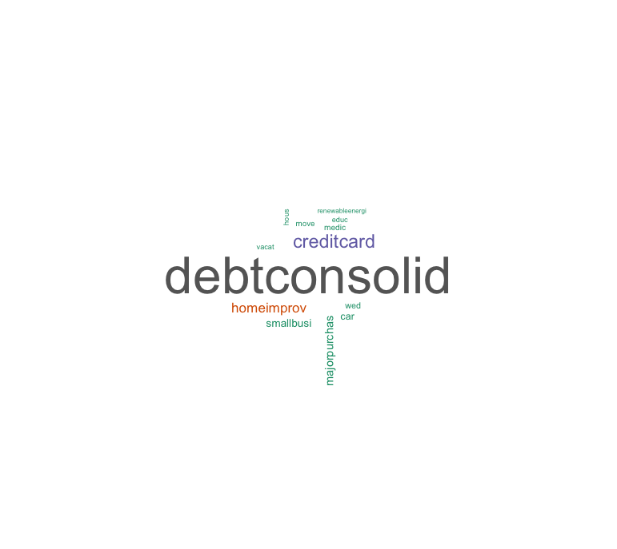

Este WordCloud muestra los titulos ingresados en la solicitud del prestamo por parte de los solicitantes. Se observa que **Consolidacion de deudas** y **Prestamos Personales** son los principales titulos.

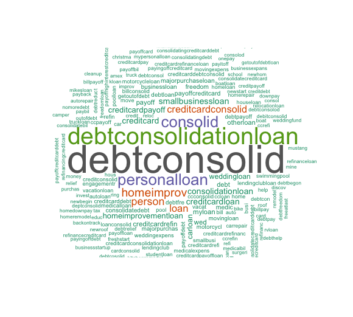

### Prestamos por Longevidad Laboral

Este boxplot muestra que la mayoria de los solicitantes de prestamos tienen mas de **10 annos** de laborar, despues los de menos de **un anno o 2 annos**.

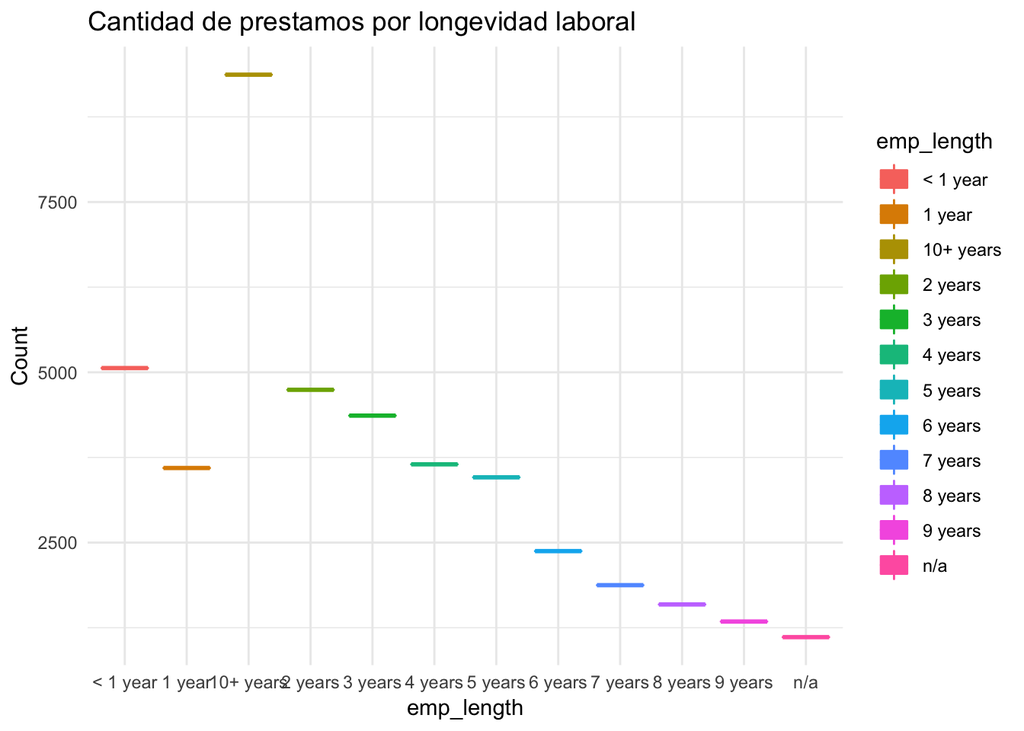

Aca se muestra el plazo de la solicitud de prestamos por el tipo de longevidad laboral, donde se observa la relacion entre el tipo de prestamo por tipo de empleado.

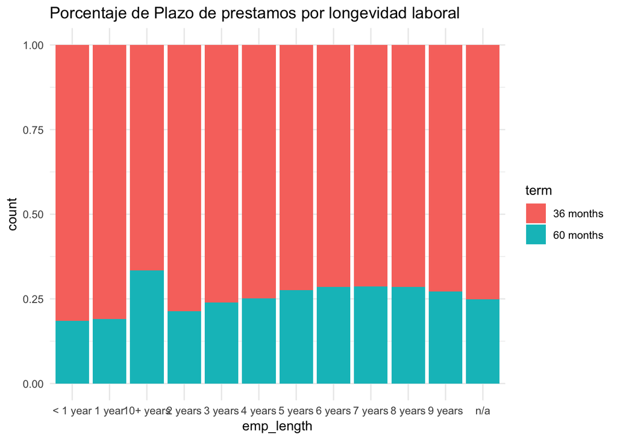

### Prestamos por propiedad de vivienda

Los prestatarios que tienen una hipoteca o que rentan son los mayores solicitantes.

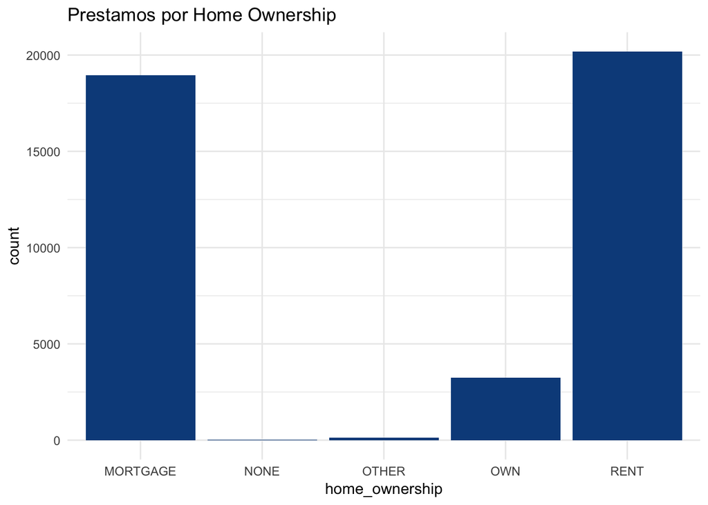

### Prestamos por Estado

Este map muestra la cantidad de prestamos que se han solicitado por el estado. Siendo **California, Nueva York, Florida** y **Texas** los top 4.

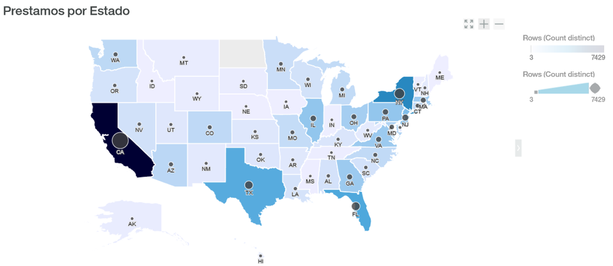